# Lista 5 - Series

#### 10. Liste os modelos com os menores BIC. Certifique-se que o melhor modelo nao possua uma ordem na extremidade da malha definida no item 9. Se houver, retorne para o passo 9 , ampliando a malha.

```r
# Listar os modelos com os menores BIC
least_BIC <- model_info %>% arrange(BIC) %>% head(10)
```

```
## [1] "Modelos com menores BIC:"
```

```
##    order seasonal_order       MAPE     RMSE      AIC      BIC
## 1  0,1,1       0,1,1,12 0.08985144 1.430953 899.0621 909.5536
## 2  0,1,2       0,1,1,12 0.08944570 1.428848 900.5666 914.5553
## 3  1,1,1       0,1,1,12 0.08953324 1.429262 900.6692 914.6579
## 4  0,1,1       1,1,1,12 0.08983963 1.431275 900.6765 914.6652
## 5  0,1,1       0,1,2,12 0.08985964 1.431329 900.7014 914.6901
## 6  2,1,0       0,1,1,12 0.09087644 1.443575 904.8032 918.7919
## 7  2,1,1       0,1,1,12 0.08959914 1.426291 901.5392 919.0251
## 8  0,1,2       1,1,1,12 0.08948017 1.429216 902.1429 919.6288
## 9  0,1,2       0,1,2,12 0.08949147 1.429281 902.1713 919.6572
## 10 1,1,1       1,1,1,12 0.08955842 1.429621 902.2522 919.7380
```

#### 11. Inicie o diagnóstico com o modelo que apresenta o menor BIC:

##### 11.1 Analise as estimativas dos parâmetros por meio da funcao sarima do pacote astsa.

```r
# Analisar as estimativas dos parâmetros do melhor modelo
# Seleciona os parâmetros do melhor modelo com base no menor BIC
best_model_params <- least_BIC[1,1]
best_model_params_seasonal = least_BIC[1,2]

order <- as.integer(unlist(strsplit(best_model_params, ",")))
best_seasonal_order <- as.integer(unlist(strsplit(best_model_params_seasonal, ",")))
seasonal_order = list(order = best_seasonal_order, period = m)

# Ajusta o modelo SARIMA com os melhores parâmetros
best_model <- sarima(train,  p = order[1], d = order[2], q = order[3] , seasonal = seasonal_order)
```

```
## <><><><><><><><><><><><><><>
##
## Coefficients:
##          Estimate     SE t.value p.value
## ma1       -0.5672 0.0590 -9.6149  0.0000
## constant   0.0662 0.0406  1.6308  0.1042
##
## sigma^2 estimated as 2.225425 on 254 degrees of freedom
##
## AIC = 3.662779  AICc = 3.662964  BIC = 3.704324
##
```

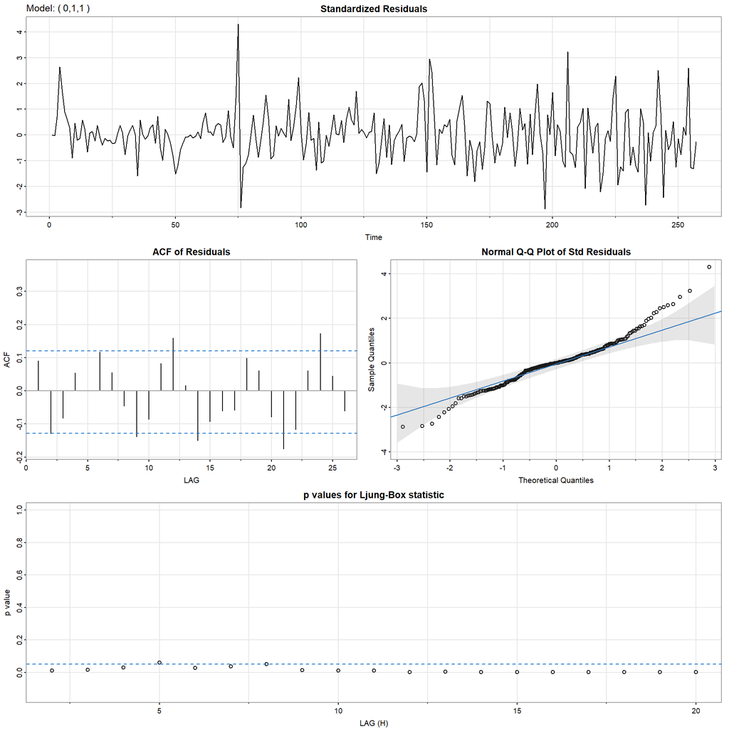

O ma1 negativo indica uma relação inversa entre as observações passadas e a atual, significando que um aumento nas observações passadas pode resultar em uma diminuição na observação atual. O ruído branco (sigma2) é considerado razoável.